# Text analysis of *The Great Gatsby* by F. Scott Fitzgerald

Mariano Viz

24/02/2021

## Summary

In this report, I conduct a text analysis of F. Scott Fitzgerald’s book *The Great Gatsby*. First, I wrangle the data to structure the text in tidy format. Next, I analyze the most frequently used words by F. Scott Fitzgerald and make plots showing the top 5 most used words by chapter and the top 100 most used words in the book. Finally, I perform a sentiment analysis using the NRC lexicon and show the results for each chapter in a bar plot. Edition used in the analysis: Fitzgerald, F. S. (2014). The great Gatsby. General Press.

## Tidy text format

```r
#Read in pdf
great_gatsby <- pdf_text("The Great Gatsby.pdf")

#Get it into a data frame and tidy format:
gatsby_df <- data.frame(great_gatsby) %>%
  mutate(text_tidy = str_split(great_gatsby, pattern = '\\n')) %>% #split by line
  unnest(text_tidy) %>% #each individual line in a row
  mutate(text_tidy = str_trim(text_tidy)) %>% #get rid of lead/tail whitespace
  slice(-(1:41)) %>%  #get rid of text before chapter 1
  mutate(chapter = case_when(str_detect(text_tidy, pattern = "Chapter") ~ text_tidy,
                             TRUE ~ NA_character_)) %>% #split by chapter (grouping variable)
  fill(chapter) %>% #fill NA values in chapter col
  separate(col = chapter, into = c("chap", "num"), sep = " ") %>%  #separate chapter number
  mutate(chapter = as.numeric(as.character(num))) #numbers to chapter col in class numeric

#Get tokens and remove stop_words:
gatsby_tok_nosw <- gatsby_df %>%
  unnest_tokens(word, text_tidy) %>% #unnest tokens
  dplyr::select(-c(great_gatsby, chap, num)) %>% #get rid of cols except for 'chapter' and 'word'
  mutate(word = str_replace(word, pattern = "’", replacement = "'")) %>% #replace ’ with ' (in stop_word words appear with ' instead of ’ -e.g.: don't != don’t)
  anti_join(stop_words) #remove stop_words
```

## Most frequently used words in *The Great Gatsby*

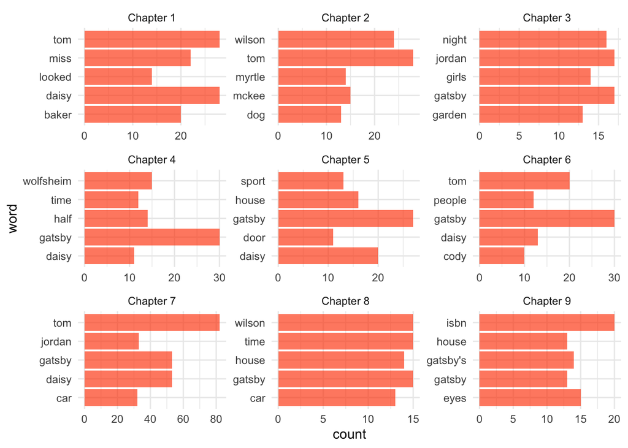

```r
#Top 5 words by chapter:
gatsby_counts <- gatsby_tok_nosw %>%
  count(chapter, word)
gatsby_top5 <- gatsby_counts %>%
  group_by(chapter) %>%
  arrange(-n) %>%
  slice(1:5)

#Plot:
chapter.labs<-c("Chapter 1", "Chapter 2", "Chapter 3", "Chapter 4", "Chapter 5", "Chapter 6", "Chapter 7", "Chapter 8", "Chapter 9")
names(chapter.labs)<-c(1, 2, 3, 4, 5, 6, 7, 8, 9)

ggplot(data = gatsby_top5, aes(x = word, y = n)) +
  geom_col(fill = "orangered1", alpha = 0.65) +
  facet_wrap(~chapter, scales = "free", labeller = labeller(chapter=chapter.labs)) +
  coord_flip() +
  theme_minimal()+
  labs(x = "word",
       y = "count")
```

**Figure 1.** Top 5 most frequently used words by chapter (1-9). Orange bars indicate total word counts for each chapter.

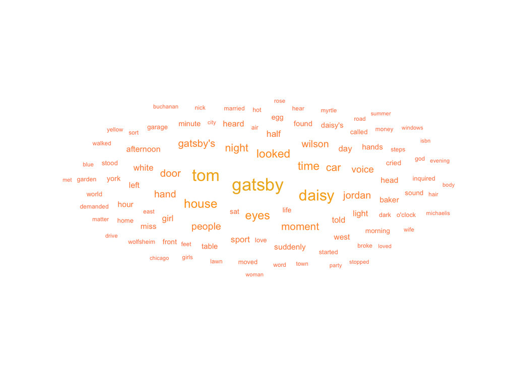

```r
#Top 100 most used words:
gatsby_top100 <- gatsby_tok_nosw %>%
  count(word) %>%
  arrange(-n) %>%
  slice(1:100)

#Word cloud plot (top 100 in the book)
gatsby_top100_wcloud <- ggplot(data = gatsby_top100, aes(label = word)) +
  geom_text_wordcloud(aes(color = n, size = n), shape = "circle") +
  scale_size_area(max_size = 6) +
  scale_color_gradientn(colors = c("coral","orange1","goldenrod2")) +
  theme_minimal()

gatsby_top100_wcloud
```

**Figure 2.** Top 100 most used words in *The Great Gatsby*. Size and color of the words in the plot reflect the frequency with which they appear in the original text.

## Sentiment analysis

```r
#Sentiment analysis (NRC lexicon)
get_sentiments(lexicon = "nrc")

garsby_sent_nrc <- gatsby_tok_nosw %>%
  inner_join(get_sentiments("nrc"))
```

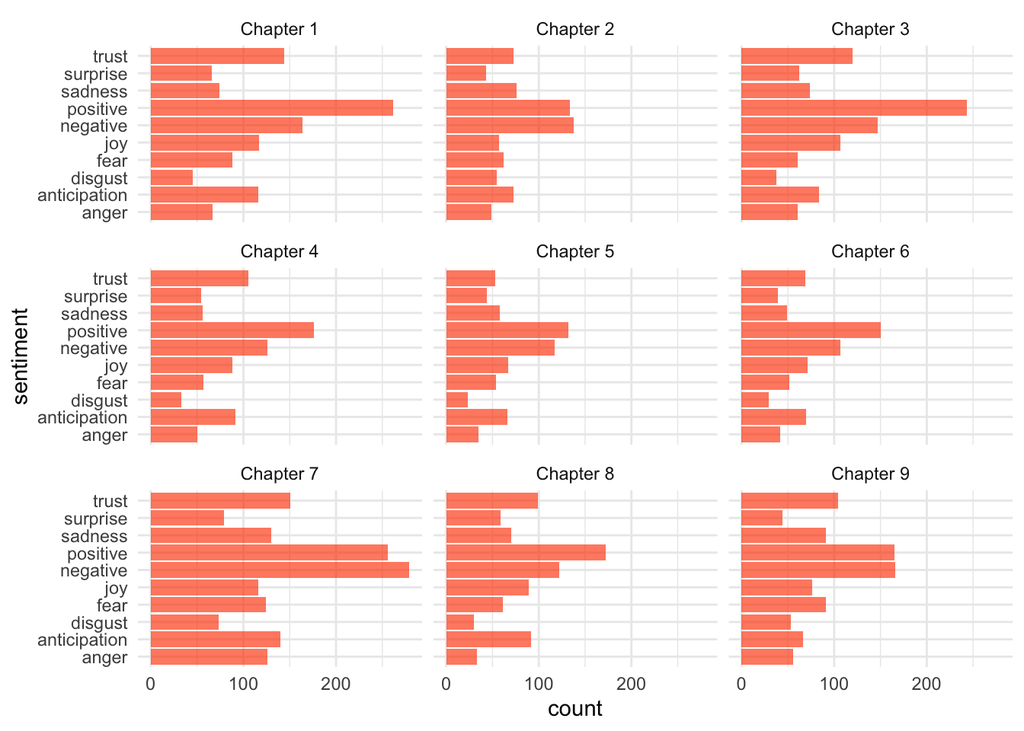

```r
#Sentiment analysis plot:
gatsby_nrc_counts <- garsby_sent_nrc %>%
  count(chapter, sentiment)

ggplot(data = gatsby_nrc_counts, aes(x = sentiment, y = n)) +
  geom_col(fill = "orangered1", alpha = 0.65) +
  facet_wrap(~chapter, labeller = labeller(chapter=chapter.labs))+
  coord_flip()+
  theme_minimal()+
  labs(x = "sentiment",
       y = "count")
```

**Figure 3.** Categorization of words by chapter based on the NRC lexicon. Orange bars show counts of words per chapter categorized by the NRC lexicon into the categories: positive, negative, anger, anticipation, disgust, fear, joy, sadness, surprise, and trust.

**Citation for NRC lexicon**: Crowdsourcing a Word-Emotion Association Lexicon, Saif Mohammad and Peter Turney, Computational Intelligence, 29 (3), 436-465, 2013.